# Vulnerabilidad Territorial en Asentamientos Irregulares de Humedales Periurbanos de Maullín

Author

Tabita Garrido

## 1. Introducción

La comuna de Maullín, en la Región de Los Lagos, presenta asentamientos humanos irregulares ubicados en zonas periurbanas con humedales activos, influencia mareal y sin instrumentos de planificación territorial. Esto genera un problema socioterritorial complejo: las personas que viven en estos sectores no cuentan con servicios básicos conectados a red pública y están expuestas a riesgos de inundación sin protocolos de evacuación.

Este trabajo analiza la vulnerabilidad territorial de 9 localidades del entorno del Santuario de la Naturaleza Humedales del Río Maullín, usando datos del Censo de Población y Vivienda 2024 (Instituto Nacional deísticas, 2024). Las localidades analizadas son: El Habal, Coyam, Puelpún, Misquihué, Olmopulli, Peñol, Chuyaquén, Chilcas y Cariquilda.

**Pregunta de investigación:** ¿Cuál es el nivel de vulnerabilidad territorial de los asentamientos irregulares en el entorno de humedales periurbanos de Maullín, medido a través de indicadores de saneamiento, vivienda precaria y vulnerabilidad social, según el CPV 2024?

**Hipótesis:** Las localidades con mayor déficit de saneamiento básico (fosa séptica + pozo) presentan al mismo tiempo mayor proporción de población vulnerable (adultos mayores y personas con discapacidad), lo que configura una vulnerabilidad territorial acumulada no abordada por la planificación comunal.

## 2. Datos y variables

La base de datos utilizada corresponde al Censo de Población y Vivienda 2024 (Instituto Nacional deísticas, 2024) del Instituto Nacional de Estadísticas, a nivel de localidad censal para la comuna de Maullín. La base contiene 36 localidades con variables de población, vivienda y servicios básicos.

Se seleccionaron las siguientes variables:

| Variable | Nivel de medición | Descripción |
| --- | --- | --- |
| Promedio de edad (`prom_edad`) | Razón | Promedio de edad de la población por localidad |
| Proporción adultos mayores (`prop_adulto_mayor`) | Razón | Personas de 60+ años sobre el total de personas |
| Riesgo sanitario (`riesgo_sanitario`) | Ordinal | Clasificación Bajo/Medio/Alto según proporción de fosa séptica + pozo |
| Tipo servicio higiénico (`tipo_serv_hig`) | Nominal | Servicio predominante: Alcantarillado, Fosa séptica, Pozo o sin servicio |

## 4. Resultados

### 4.1 Tabla descriptiva

Tabla 1. Estadísticos descriptivos de variables numéricas

| Variable | Mínimo | Mediana | Media | Máximo |
| --- | --- | --- | --- | --- |
| Prom. edad | 36.700 | 45.850 | 45.550 | 58.400 |
| Prop. adulto mayor | 0.158 | 0.327 | 0.326 | 0.544 |
| Prop. discapacidad | 0.000 | 0.178 | 0.176 | 0.429 |
| Prop. fosa séptica | 0.050 | 0.297 | 0.307 | 0.667 |

### 4.2 Tablas de frecuencia

Tabla 2. Frecuencia de riesgo sanitario por localidad

| Nivel | Frecuencia |
| --- | --- |
| Bajo | 5 |
| Medio | 8 |
| Alto | 23 |

La Tabla 2 muestra que el riesgo sanitario alto es la categoría predominante en la comuna de Maullín, concentrando 23 de las 36 localidades analizadas. Esto significa que en casi dos tercios del territorio comunal, más de la mitad de las viviendas dependen de fosa séptica o pozo como sistema de saneamiento. Las localidades con riesgo bajo son apenas 5, todas ubicadas en zonas urbanas con acceso a alcantarillado público.

Tabla 3. Frecuencia de tipo de servicio higiénico predominante

| Tipo | Frecuencia |
| --- | --- |
| Alcantarillado | 8 |
| Fosa séptica | 17 |
| Pozo o sin servicio | 11 |

De las 36 localidades, 23 presentan un nivel de riesgo sanitario alto, 8 un riesgo medio y solo 5 un riesgo bajo. Esto indica que la mayor parte del territorio comunal carece de condiciones adecuadas de saneamiento. Al analizar el tipo de servicio higiénico predominante, solo 8 localidades cuentan con alcantarillado, mientras que 17 dependen de fosa séptica y 11 de pozo o no tienen servicio.

### 4.3 Gráficos

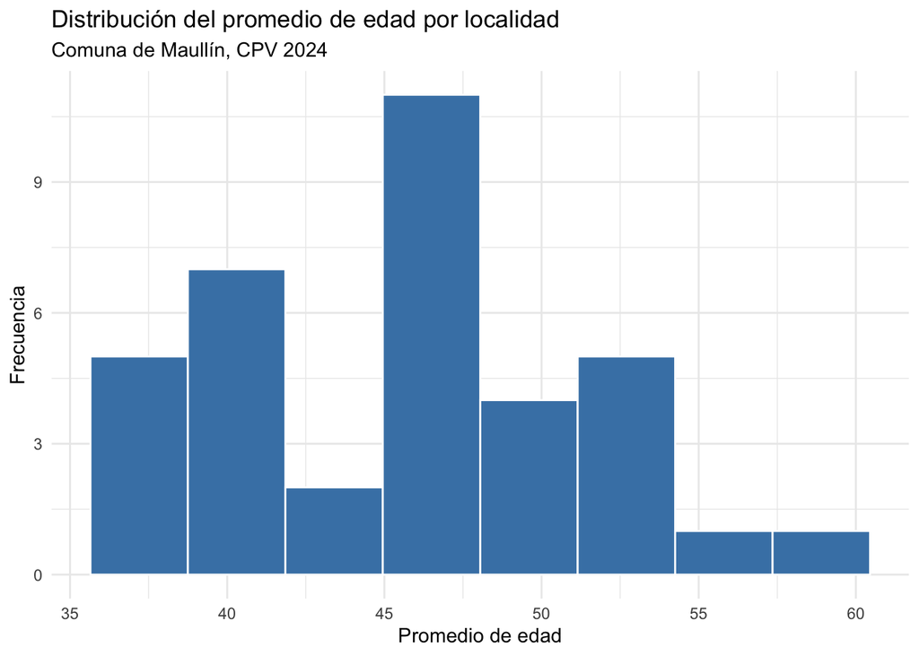

Distribución del promedio de edad por localidad

La distribución del promedio de edad por localidad muestra que la mayoría de las localidades de Maullín se concentra en un rango entre los 38 y 52 años. Sin embargo, existe un grupo de localidades que supera los 50 años de promedio, lo que indica una población envejecida en sectores rurales más aislados. La media comunal de 45,5 años es considerablemente más alta que el promedio nacional, lo cual se explica por la migración de población joven hacia centros urbanos y la permanencia de adultos mayores en localidades rurales sin acceso a servicios. Este envejecimiento tiene implicancias directas para la planificación territorial, ya que una población de mayor edad requiere acceso prioritario a servicios de salud y condiciones de habitabilidad adecuadas.

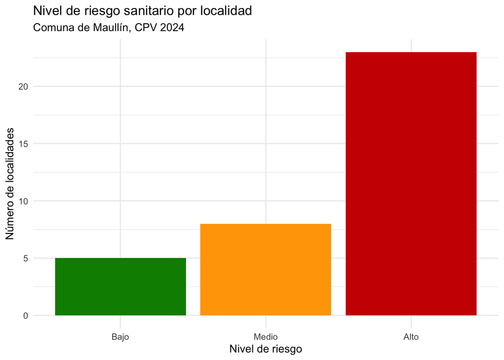

Nivel de riesgo sanitario por localidad

El gráfico de riesgo sanitario evidencia una situación crítica a nivel comunal: 23 de las 36 localidades presentan un nivel de riesgo alto, es decir, más del 50% de sus viviendas dependen de fosa séptica o pozo como sistema de evacuación de aguas servidas. Solo 5 localidades alcanzan un nivel bajo, las cuales corresponden a las zonas urbanas de Maullín y Carelmapu que cuentan con conexión a red de alcantarillado. Las 8 localidades restantes se ubican en un nivel medio. Esta distribución refleja una desigualdad territorial marcada entre las áreas urbanas y rurales de la comuna, donde la gran mayoría de la población rural no cuenta con infraestructura sanitaria adecuada, generando riesgos de contaminación hídrica especialmente graves en zonas cercanas a cuerpos de agua como los humedales del Río Maullín.

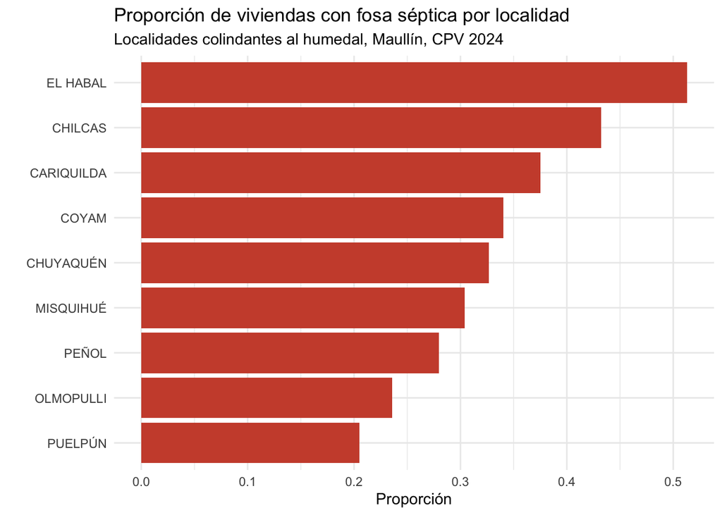

Proporción de fosa séptica en localidades del humedal

Entre las 9 localidades colindantes al humedal, El Habal y Chilcas presentan las mayores proporciones de fosa séptica, superando el 40% de sus viviendas. Ninguna de estas localidades cuenta con alcantarillado como servicio predominante.

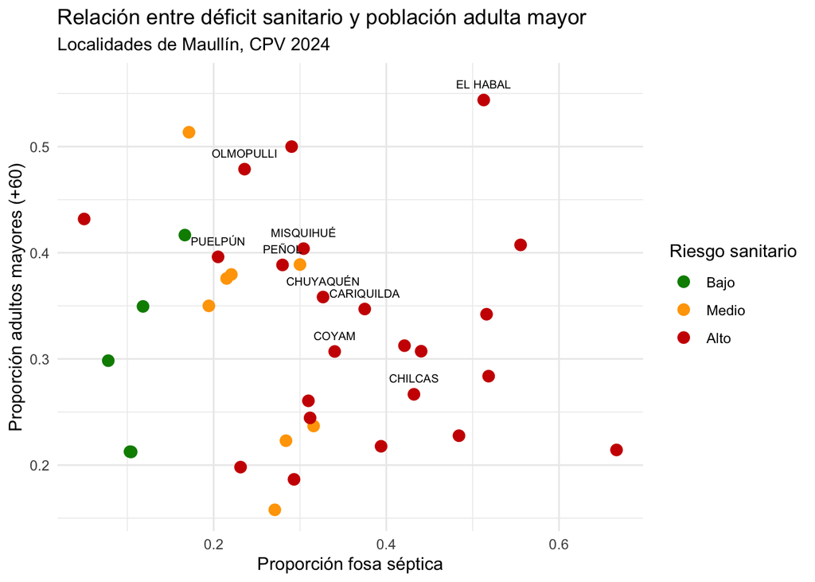

Relación entre déficit sanitario y población adulta mayor

## 5. Conclusiones

Estos hallazgos evidencian la necesidad de incorporar estas localidades en los instrumentos de planificación comunal, tal como lo establece el SIEDU (Ministerio de Vivienda y Urbanismo, 2022), considerando los indicadores de vulnerabilidad comunal (Ministerio de Desarrollo Social y Familia, 2024) y los antecedentes hídricos del PERHC Maullín (Dirección General de Aguas, 2025) y de diseñar protocolos de emergencia diferenciados que consideren las características específicas de la población residente. La contaminación hídrica derivada del uso masivo de fosas sépticas en zonas de humedal activo representa un riesgo ambiental y sanitario que requiere atención prioritaria.

## 6. Referencias

Dirección General de Aguas. (2025). *Plan estratégico de recursos hídricos en cuencas — maullín 2025*. DGA - MOP.

Instituto Nacional deísticas. (2024). *Censo de población y vivienda 2024*. https://www.ine.gob.cl/estadisticas/sociales/censos-de-poblacion-y-vivienda/censo-de-poblacion-y-vivienda

Ministerio de Desarrollo Social y Familia. (2024). *Índice de vulnerabilidad por comuna*. MIDESO.

Ministerio de Vivienda y Urbanismo. (2022). *Sistema de indicadores y estándares de desarrollo urbano (SIEDU)*. MINVU.